# Summer Harper

##### Contact Information:

cell phone: (123)456-7890  
email address: slh293@cornell.edu

## Education

**Bachelors of Chaos, Cornell University, CALS**

*Expected Graduation: May 2023*

Magician major, with a concentration in Magical Forests

GPA: 1,000,000.00

## Research Experience

**Cornell University Department of Un-Natural Resources – Research Assistant**

- Assisted with a long-term project seeking to understand the threat of drought to Magical Forests across the globe.
- Collaborated with aliens to develop solutions across all universes.
- Collected high quality demography data of monoculture magical tree forests.

## Work Experience

**Willy Wonka Chocolate Factory Inc.**

**2027**

- Provided feedback and suggestions regarding new products
- Assisted in maintaining a positve work environment

**United States Forest Service - Department of Mobile Plants**

**2031**

- Assisted in safe migration of mobile woody plants across built environments.
- Established partnerships between mobile crops and farmers, in order to ensure farmer livelihoods as well as crop standard of living.

## Awards

- I hold the school record for number of “good behavior” stickers earned in 3rd grade.

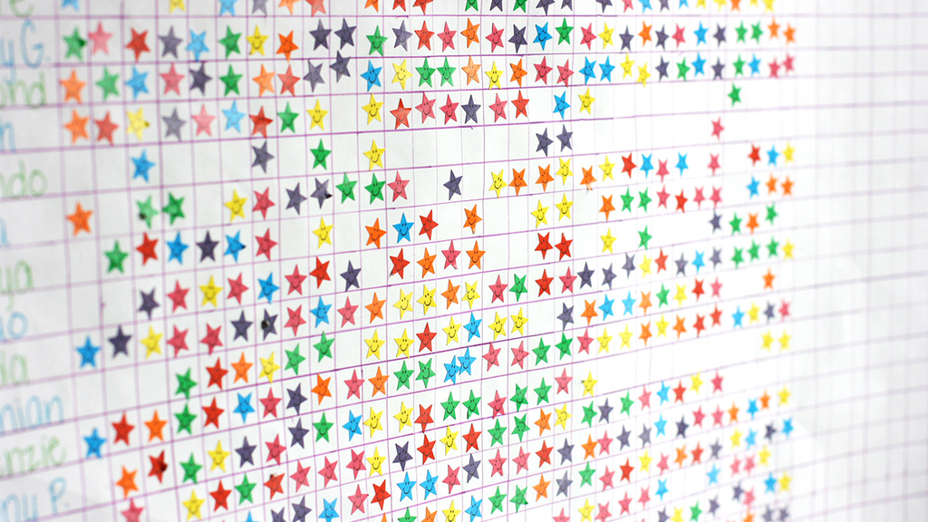

- 2023 Tallest Tree Climbed Award: This honor is awarded to the student who successfully climbs the tallest tree on campus.

[figure not shown]